# Hankowsky_HW8

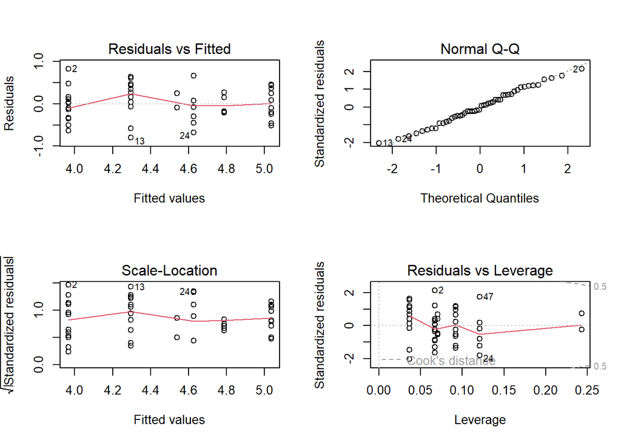

```r
# REGRESSION ANALYSIS - PART B
hurricane_b_lm1 <- lm(log_stormindex ~ WestAfrica_cat + Temperature + WestAfrica_cat:Temperature, data = hurricane)

par(mfrow=c(2,2))
plot(hurricane_b_lm1)
```

```r
#refit without interaction and test for interaction effect
hurricane_b_lm2 <- update(hurricane_b_lm1, ~ . - WestAfrica_cat:Temperature)
anova(hurricane_b_lm2, hurricane_b_lm1) # no evidence for an interaction effect, p-value = 0.60
```

```
## Analysis of Variance Table
##
## Model 1: log_stormindex ~ WestAfrica_cat + Temperature
## Model 2: log_stormindex ~ WestAfrica_cat + Temperature + WestAfrica_cat:Temperature
##   Res.Df    RSS Df Sum of Sq      F Pr(>F)
## 1     45 7.1163
## 2     44 7.0724  1   0.04398 0.2736 0.6035
```

```r
#run optimal model, question asks for both West Africa wetness and El Nino temp to be in the model
hurricane_b_lm <- lm(log_stormindex ~ WestAfrica_cat + Temperature, data = hurricane)

summary(hurricane_b_lm)
```

```
##
## Call:
## lm(formula = log_stormindex ~ WestAfrica_cat + Temperature, data = hurricane)
##
## Residuals:
##      Min       1Q   Median       3Q      Max
## -0.79350 -0.26273 -0.00785  0.29715  0.80576
##
## Coefficients:
##                 Estimate Std. Error t value Pr(>|t|)
## (Intercept)      4.29001    0.07472  57.416  < 2e-16 ***
## WestAfrica_cat1  0.47897    0.12756   3.755 0.000496 ***
## Temperature     -0.29998    0.07563  -3.966 0.000259 ***
## ---
## Signif. codes:  0 '***' 0.001 '**' 0.01 '*' 0.05 '.' 0.1 ' ' 1
##
## Residual standard error: 0.3977 on 45 degrees of freedom
## Multiple R-squared:  0.5122, Adjusted R-squared:  0.4905
## F-statistic: 23.62 on 2 and 45 DF,  p-value: 9.676e-08
```

```r
anova(hurricane_b_lm)
```

```
## Analysis of Variance Table
##
## Response: log_stormindex
##                Df Sum Sq Mean Sq F value    Pr(>F)
## WestAfrica_cat  1 4.9843  4.9843  31.518 1.163e-06 ***
## Temperature     1 2.4876  2.4876  15.730 0.0002591 ***
## Residuals      45 7.1163  0.1581
## ---
## Signif. codes:  0 '***' 0.001 '**' 0.01 '*' 0.05 '.' 0.1 ' ' 1
```

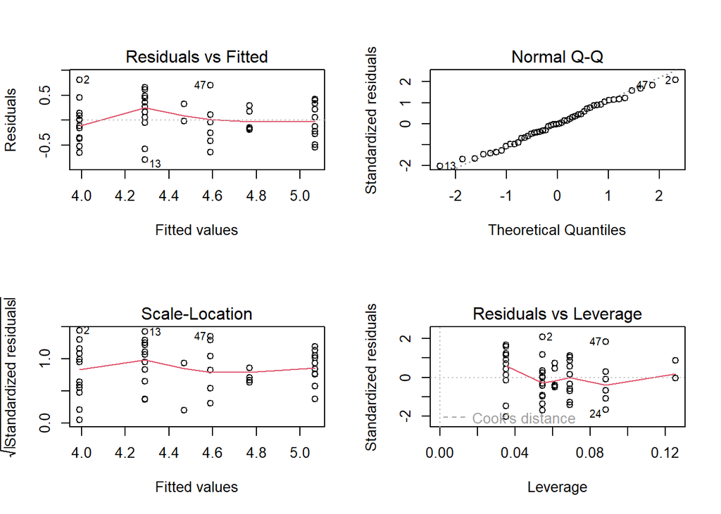

```r
par(mfrow=c(2,2))
plot(hurricane_b_lm)
```

```r
# PART C - Compare the SS residuals and residual df
a1 <- anova(hurricane_a_lm)
a2 <- anova(hurricane_b_lm)

#extracting the SS residuals
a1["Residuals", "Sum Sq"]
```

```
## [1] 6.888113
```

```r
a2["Residuals", "Sum Sq"]
```

```
## [1] 7.116333
```

```r
#extracting the residual df
a1["Residuals", "Df"]
```

```
## [1] 44
```

```r
a2["Residuals", "Df"]
```

```
## [1] 45
```

Part B: A log-transformation was conducted based problem statement in the question. A saturated model was fit to the log-transformed storm index data with West African wetness, temperature (continuous) and the interaction of West African wetness and temperature as explanatory variables. A reduced model was fit without the interaction term, and there was no evidence for an interaction effect (Extra Sum of Squares F-test, p-value = 0.60). The diagnostic plots show no problematic patterns in the model fit.

Part C: The sum of squared residuals and the residual degrees of freedom were slightly different in my analysis. The degrees of freedom are different for numeric and categorical variables. The degrees of freedom for a categorical variable are dependent on the number of levels in the variable, whereas thea continuous variable only has one degree of freedom.

Part D: The temperature term should be treated as categorical. It has three levels (1, 0, -1). If you were to square the temperature it would essentially get rid of the information captured in that term. It would not be appropriate to treat the temperature term as continuous in this study.

**Basic 13.18_3rd** I don’t know quite where you went wrong on each part of the question, but you did. Part A asked for the Residual sum of squares and df, which you didn’t provide. Part b asked again for the Residual ss and df, which are identical to those found in A. The answer to c) is that they are identical and asks why. Your answer to d is correct. **Score 4/5**

# Supplemental Problems

## 13.17

Dinosaur Extinctions—An Observational Study. About 65 million years ago, the dinosaurs suffered a mass extinction virtually overnight (in geologic time).What happened in this period, the Cretaceous–Tertiary (KT) boundary, that could have produced such calamity? Among many clues, one that all scientists regard as crucial is a layer of iridium-rich dust that was deposited over much of the earth at that time. Data from one of the first discoveries of this layer are shown inDisplay 13.22. The diagram traces iridium concentrations in soil samples taken from extensive shale and limestone deposits at Gubbio, Italy. Iridium (parts per trillium) is graphed against the depth at which samples were taken, with depth giving a crude measure of historic time.

Iridium is a trace element present in most soils. But concentrations as high as those at the peak near 347 meters, at the KT boundary, can only occur in association with highly unusual events, such as volcanic eruptions or meteor impacts. So the theory is that such an event caused a massive dust cloud that blanketed the earth for years, killing off animals and their food sources. Butwas the cause a meteor (coming down on the Yucatan peninsula in central America) or volcanic eruptions (centered in southern China)? Two articles debating the issue appeared in the October 1990 issue of Scientific American—W. Alvarez and F. Asaro, “What Caused the Mass Extinction? An Extraterrestrial Impact,” Scientific American 263(4): 76–84, and E. Courtillot, “What Caused the Mass Extinction? A Volcanic Eruption,” Scientific American 263(4): 85–93. A crucial issue in the debate is the shape of the iridium trace because the timing and extent of the source give clues to its nature.

The raw data are provided in Display 13.23. (a) Fit the two-way, saturated model to the untransformed data and draw a plot of the residuals versus estimated means to see if a transformation is suggested. (b) Fit the two-way model (after transformation if appropriate) and test for interaction, using a multiple regression routine. (c) If appropriate with your statistical software, repeat part (b) using an analysis of variance routine.

```r
#Read-In the data
dinos <- Sleuth3::ex1317

#take a look at the dataset
head(dinos)
```

```
##   Iridium    Strata DepthCat
## 1      75 Limestone        1
## 2     200 Limestone        1
## 3     120 Limestone        2
## 4     310 Limestone        2
## 5     290 Limestone        3
## 6     450 Limestone        3
```

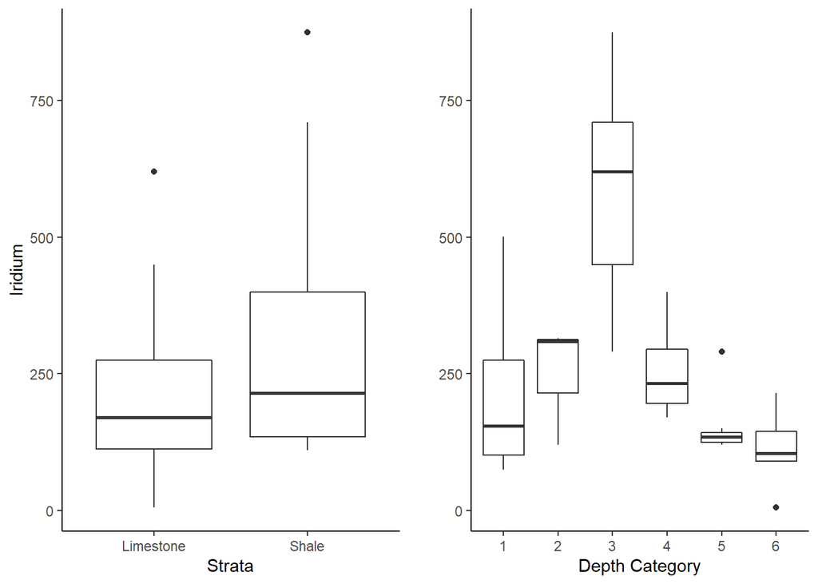

```r
#transforming the data for later in the problem
dinos <- dinos %>%
  mutate(log_iridium = log(Iridium))

#take a look at the boxplots
p31 <- dinos %>%
  ggplot() +
  geom_boxplot(aes(x = Strata, y = Iridium)) +
  theme_classic()

p32 <- dinos %>%
  ggplot() +
  geom_boxplot(aes(x = DepthCat, y = Iridium)) +
  labs(x = "Depth Category", y = "") +
  theme_classic()

grid.arrange(p31, p32, nrow = 1)
```

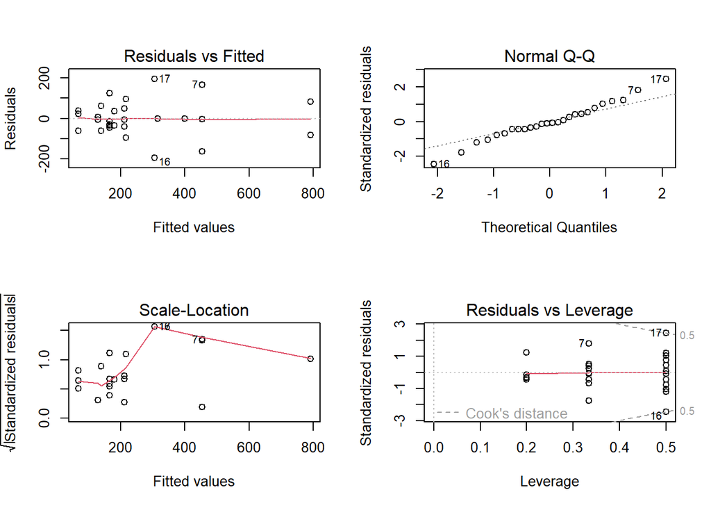

```r
# PART A
dinos_a_lm1 <- lm(Iridium ~ Strata + DepthCat + Strata:DepthCat, data = dinos)

par(mfrow=c(2,2))
plot(dinos_a_lm1)
```

```r
#refit without interaction and test for interaction effect
dinos_a_lm2 <- update(dinos_a_lm1, ~ . - Strata:DepthCat)
anova(dinos_a_lm2, dinos_a_lm1) # no evidence for an interaction effect, p-value = 0.43
```

```
## Analysis of Variance Table
##
## Model 1: Iridium ~ Strata + DepthCat
## Model 2: Iridium ~ Strata + DepthCat + Strata:DepthCat
##   Res.Df    RSS Df Sum of Sq      F Pr(>F)
## 1     21 268401
## 2     16 202878  5     65523 1.0335 0.4314
```

```r
#run optimal model
dinos_a_lm <- lm(Iridium ~ Strata + DepthCat, data = dinos)

summary(dinos_a_lm)
```

```
##
## Call:
## lm(formula = Iridium ~ Strata + DepthCat, data = dinos)
##
## Residuals:
##      Min       1Q   Median       3Q      Max
## -236.713  -64.993   -2.625   61.504  201.642
##
## Coefficients:
##             Estimate Std. Error t value Pr(>|t|)
## (Intercept)   143.64      60.88   2.359  0.02807 *
## StrataShale   155.72      45.24   3.442  0.00244 **
## DepthCat2      52.79      86.67   0.609  0.54905
## DepthCat3     383.07      75.97   5.042 5.43e-05 ***
## DepthCat4      76.18      80.74   0.944  0.35613
## DepthCat5    -100.58      71.52  -1.406  0.17424
## DepthCat6     -93.93      75.97  -1.236  0.22998
## ---
## Signif. codes:  0 '***' 0.001 '**' 0.01 '*' 0.05 '.' 0.1 ' ' 1
##
## Residual standard error: 113.1 on 21 degrees of freedom
## Multiple R-squared:  0.7676, Adjusted R-squared:  0.7012
## F-statistic: 11.56 on 6 and 21 DF,  p-value: 9.872e-06
```

```r
anova(dinos_a_lm)
```

```
## Analysis of Variance Table
##
## Response: Iridium
##           Df Sum Sq Mean Sq F value    Pr(>F)
## Strata     1  76407   76407  5.9781   0.02339 *
## DepthCat   5 810293  162059 12.6796 9.337e-06 ***
## Residuals 21 268401   12781
## ---
## Signif. codes:  0 '***' 0.001 '**' 0.01 '*' 0.05 '.' 0.1 ' ' 1
```

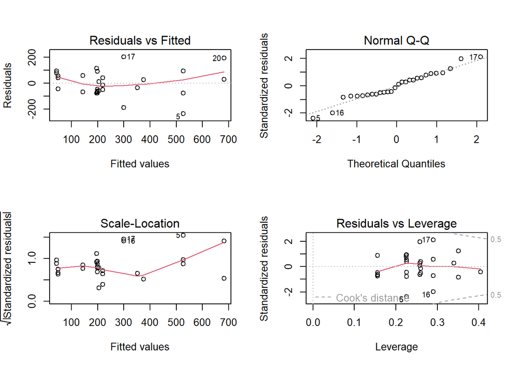

```r
par(mfrow=c(2,2))
plot(dinos_a_lm)
```

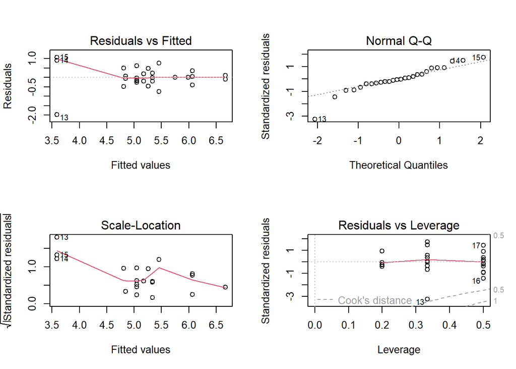

```r
# PART B
dinos_b_lm1 <- lm(log_iridium ~ Strata + DepthCat + Strata:DepthCat, data = dinos)

par(mfrow=c(2,2))
plot(dinos_b_lm1)
```

```r
#refit without interaction and test for interaction effect
dinos_b_lm2 <- update(dinos_b_lm1, ~ . - Strata:DepthCat)
anova(dinos_b_lm2, dinos_b_lm1) # no evidence for an interaction effect, p-value = 0.79
```

```
## Analysis of Variance Table
##
## Model 1: log_iridium ~ Strata + DepthCat
## Model 2: log_iridium ~ Strata + DepthCat + Strata:DepthCat
##   Res.Df     RSS Df Sum of Sq      F Pr(>F)
## 1     21 10.3020
## 2     16  8.9601  5    1.3419 0.4792 0.7866
```

```r
#run optimal model
dinos_b_lm <- lm(log_iridium ~ Strata + DepthCat, data = dinos)

summary(dinos_b_lm)
```

```
##
## Call:
## lm(formula = log_iridium ~ Strata + DepthCat, data = dinos)
##
## Residuals:
##      Min       1Q   Median       3Q      Max
## -2.33228 -0.29496  0.01974  0.43138  0.73288
##
## Coefficients:
##             Estimate Std. Error t value Pr(>|t|)
## (Intercept)   4.7827     0.3772  12.680 2.62e-11 ***
## StrataShale   0.7010     0.2803   2.501   0.0207 *
## DepthCat2     0.4092     0.5370   0.762   0.4546
## DepthCat3     1.2465     0.4707   2.648   0.0150 *
## DepthCat4     0.5448     0.5002   1.089   0.2884
## DepthCat5    -0.2929     0.4431  -0.661   0.5157
## DepthCat6    -0.8410     0.4707  -1.787   0.0884 .
## ---
## Signif. codes:  0 '***' 0.001 '**' 0.01 '*' 0.05 '.' 0.1 ' ' 1
##
## Residual standard error: 0.7004 on 21 degrees of freedom
## Multiple R-squared:   0.59,  Adjusted R-squared:  0.4729
## F-statistic: 5.038 on 6 and 21 DF,  p-value: 0.002422
```

```r
anova(dinos_b_lm)
```

```
## Analysis of Variance Table
##
## Response: log_iridium
##           Df  Sum Sq Mean Sq F value   Pr(>F)
## Strata     1  1.8727 1.87267  3.8173 0.064174 .
## DepthCat   5 12.9550 2.59101  5.2816 0.002698 **
## Residuals 21 10.3020 0.49057
## ---
## Signif. codes:  0 '***' 0.001 '**' 0.01 '*' 0.05 '.' 0.1 ' ' 1
```

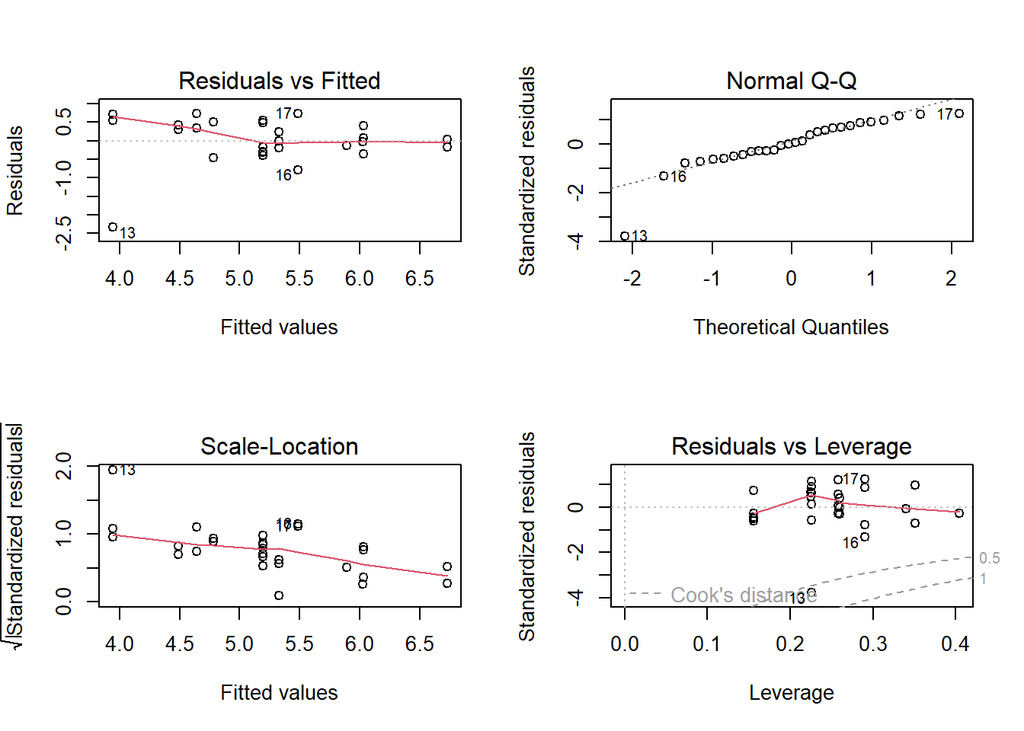

```r
par(mfrow=c(2,2))
plot(dinos_b_lm)
```

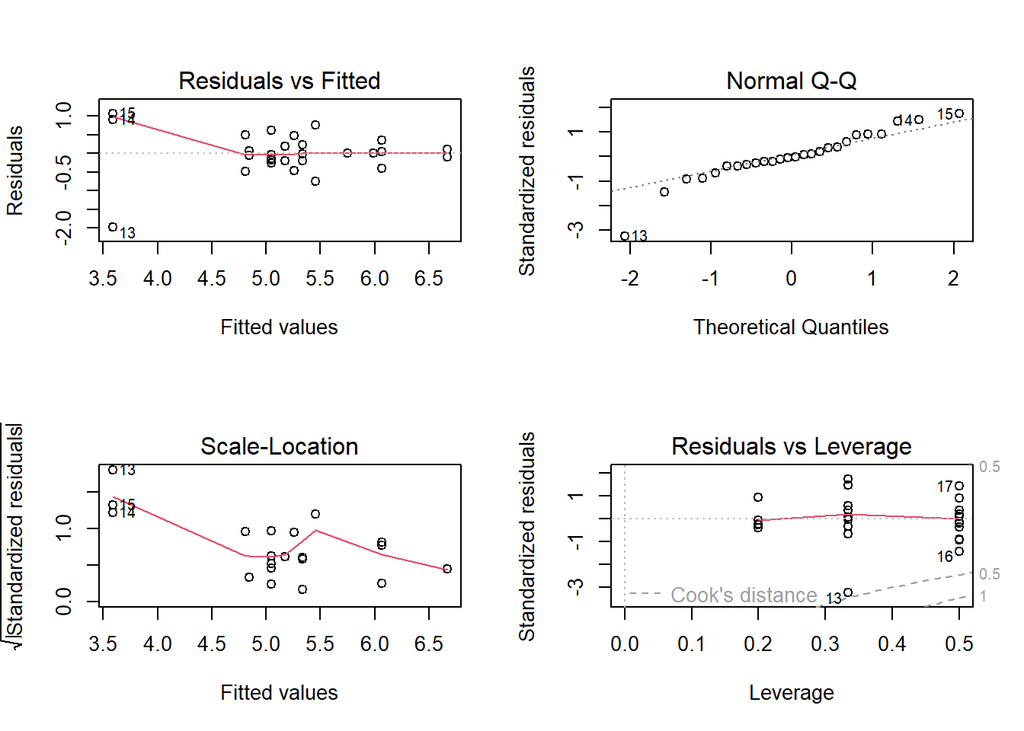

```r
# PART C
dinos_c_aov1 <- aov(log_iridium ~ Strata + DepthCat + Strata:DepthCat, data = dinos)

par(mfrow=c(2,2))
plot(dinos_c_aov1)
```

```r
#refit without interaction and test for interaction effect
dinos_c_aov2 <- update(dinos_c_aov1, ~ . - Strata:DepthCat)
anova(dinos_c_aov2, dinos_c_aov1) # no evidence for an interaction effect, p-value = 0.79
```

```
## Analysis of Variance Table
##
## Model 1: log_iridium ~ Strata + DepthCat
## Model 2: log_iridium ~ Strata + DepthCat + Strata:DepthCat
##   Res.Df     RSS Df Sum of Sq      F Pr(>F)
## 1     21 10.3020
## 2     16  8.9601  5    1.3419 0.4792 0.7866
```

```r
#run optimal model
dinos_c_aov <- aov(log_iridium ~ Strata + DepthCat, data = dinos)

summary(dinos_c_aov)
```

```
##             Df Sum Sq Mean Sq F value Pr(>F)
## Strata       1  1.873  1.8727   3.817 0.0642 .
## DepthCat     5 12.955  2.5910   5.282 0.0027 **
## Residuals   21 10.302  0.4906
## ---
## Signif. codes:  0 '***' 0.001 '**' 0.01 '*' 0.05 '.' 0.1 ' ' 1
```

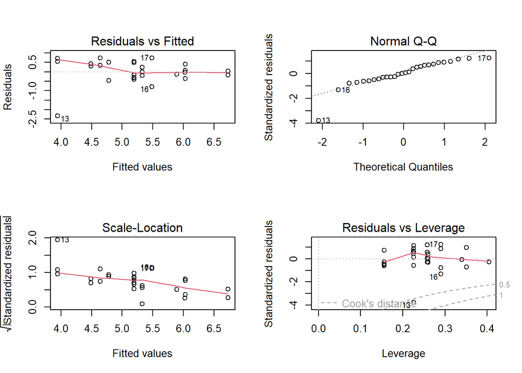

```r
par(mfrow=c(2,2))
plot(dinos_c_aov)
```

Part A: A regression model was fit with the raw iridium data with stratum, depth category and the interaction of stratum and depth category as explanatory variables. A reduced model was fit without the interaction term, and there was no evidence for an interaction effect (Extra Sum of Squares F-test, p-value = 0.43). However, the residuals for this model were extraordinarly large, so a log-transformation was conducted for Part B of the problem.

**Supplemental 13.17_3rd** Excellent work on the problem. The residuals still had problems even after the log transform but there’s not much too be done. A Box-Cox transformation might find a slightly better transform than log, but the data are just messy. **Score 2.5/2.5**

## 13.21

Pygmalion. The term Pygmalion effect (used in the Section 13.1.2 data problem) originated with the 1960s’ work of psychologist Robert Rosenthal and elementary school principal Lenore Jacobson, who conducted a randomized block experiment on the children in Jacobson’s elementary school. In each classroom (i.e., for each block of students), they assigned roughly 20% of the students to a “likely to excel” treatment group and the remainder to a control group. After all students took a standardized test at the begining of the school year, Rosenthal and Jacobson identified to teachers those students that had been indicated by the intelligence test as very likely to excel in the coming year. This was false information, though. The “likely to excel” students were simply those who had been assigned by a chance mechanism to the “likely to excel” treatment group. The researchers deceived the teachers with this false information to create artificial expectations and to explore the effect of those expectations on student test score gains. Display 13.26 is a partial listing of a data set simulated to match the summary statistics and conclusions from Table A-7 of Rosenthal and Jacobson’s report (R. Rosenthal, and L. Jacobson, 1968, Pygmalion in the Classroom: Teacher Expectation and Pupil’s Intellectual Development, Holt, Rinehart, andWinston, Inc.). Analyze the data to summarize the evidence that teachers’ expectations affect student test score gains. Write a statistical report of your conclusions.

```r
#Read-In the data
pygmalion <- Sleuth3::ex1321

#take a look at the dataset
head(pygmalion)
```

```
##   Student Grade Class Treatment Gain
## 1       1     1    1a   control   -4
## 2       2     1    1a   control    0
## 3       3     1    1a   control  -19
## 4       4     1    1a   control   24
## 5       5     1    1a   control   19
## 6       6     1    1a   control   10
```

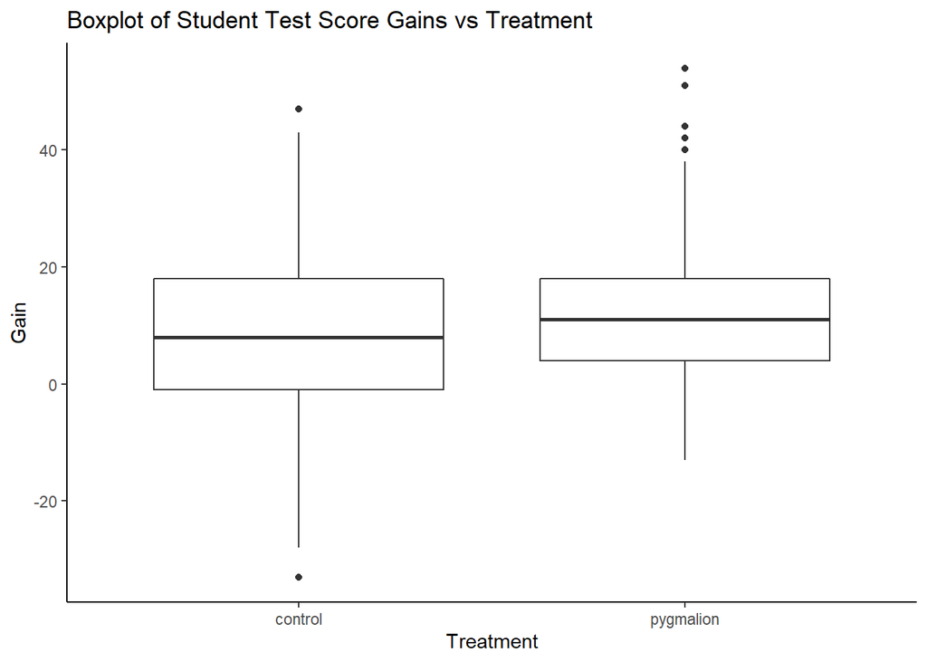

```r
#take a look at the boxplots
pygmalion %>%
  ggplot() +
  geom_boxplot(aes(x = Treatment, y = Gain)) +
  labs(title = "Boxplot of Student Test Score Gains vs Treatment") +
  theme_classic()
```

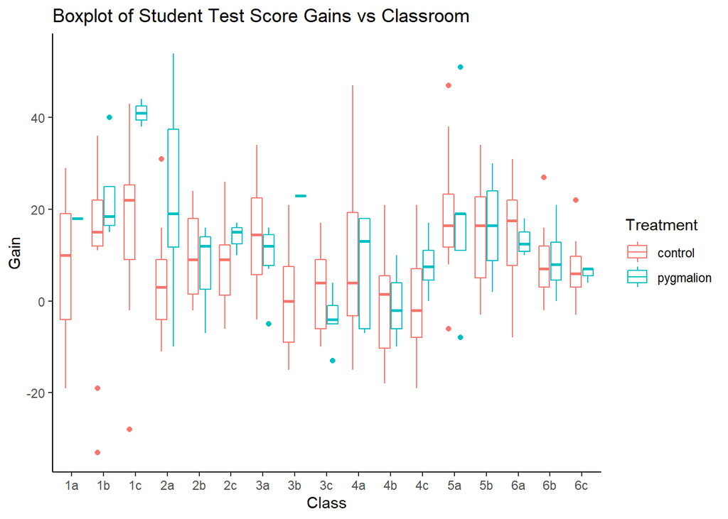

```r
pygmalion %>%
  ggplot() +
  geom_boxplot(aes(x = Class, y = Gain, color = Treatment)) +
  labs(title = "Boxplot of Student Test Score Gains vs Classroom") +
  theme_classic()
```

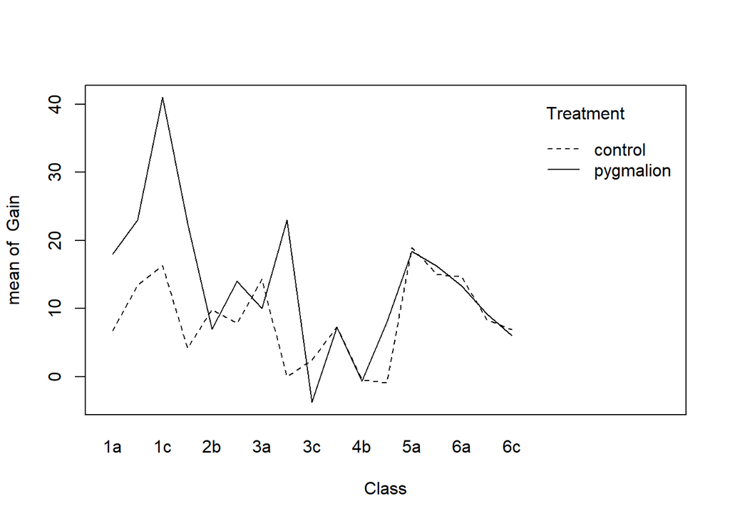

```r
#take a look at interaction plot
with(pygmalion, interaction.plot(Class, Treatment, Gain))
```

```r
# REGRESSION ANALYSIS
pygmalion_lm1 <- lm(Gain ~ Treatment + Class + Treatment:Class, data = pygmalion)

summary(pygmalion_lm1)
```

```
##
## Call:
## lm(formula = Gain ~ Treatment + Class + Treatment:Class, data = pygmalion)
##
## Residuals:
##     Min      1Q  Median      3Q     Max
## -46.467  -7.572   0.419   7.150  39.722
##
## Coefficients:
##                            Estimate Std. Error t value Pr(>|t|)
## (Intercept)                  6.7647     2.9507   2.293  0.02260 *
## Treatmentpygmalion          11.2353    12.5188   0.897  0.37022
## Class1b                      6.7020     4.3098   1.555  0.12104
## Class1c                      9.5478     4.2376   2.253  0.02501 *
## Class2a                     -2.6068     4.0616  -0.642  0.52151
## Class2b                      3.0924     4.3908   0.704  0.48182
## Class2c                      1.0924     4.3908   0.249  0.80369
## Class3a                      7.5686     4.5871   1.650  0.10004
## Class3b                     -6.8314     4.3098  -1.585  0.11405
## Class3c                     -4.3032     4.4825  -0.960  0.33787
## Class4a                      0.5131     4.1146   0.125  0.90085
## Class4b                     -7.2022     4.2376  -1.700  0.09030 .
## Class4c                     -7.6980     4.3098  -1.786  0.07513 .
## Class5a                     12.1728     4.2376   2.873  0.00438 **
## Class5b                      8.2353     4.8485   1.699  0.09050 .
## Class6a                      7.8353     4.0134   1.952  0.05188 .
## Class6b                      1.5430     4.4825   0.344  0.73093
## Class6c                      0.1520     4.5871   0.033  0.97360
## Treatmentpygmalion:Class1b  -1.7020    14.2686  -0.119  0.90514
## Treatmentpygmalion:Class1c  13.4522    15.4913   0.868  0.38592
## Treatmentpygmalion:Class2a   7.1068    13.7543   0.517  0.60577
## Treatmentpygmalion:Class2b -14.0924    14.7184  -0.957  0.33914
## Treatmentpygmalion:Class2c  -5.0924    14.7184  -0.346  0.72960
## Treatmentpygmalion:Class3a -15.5686    13.6952  -1.137  0.25657
## Treatmentpygmalion:Class3b  11.8314    17.7371   0.667  0.50528
## Treatmentpygmalion:Class3c -17.4968    14.0609  -1.244  0.21439
## Treatmentpygmalion:Class4a -11.3131    13.9480  -0.811  0.41799
## Treatmentpygmalion:Class4b -11.4645    14.6735  -0.781  0.43527
## Treatmentpygmalion:Class4c  -2.3020    14.2686  -0.161  0.87195
## Treatmentpygmalion:Class5a -11.7728    13.9848  -0.842  0.40059
## Treatmentpygmalion:Class5b  -9.9853    14.4404  -0.691  0.48982
## Treatmentpygmalion:Class6a -12.5853    14.1819  -0.887  0.37560
## Treatmentpygmalion:Class6b -10.2930    14.3217  -0.719  0.47291
## Treatmentpygmalion:Class6c -12.1520    14.7782  -0.822  0.41160
## ---
## Signif. codes:  0 '***' 0.001 '**' 0.01 '*' 0.05 '.' 0.1 ' ' 1
##
## Residual standard error: 12.17 on 286 degrees of freedom
## Multiple R-squared:  0.269,  Adjusted R-squared:  0.1846
## F-statistic: 3.189 on 33 and 286 DF,  p-value: 8.209e-08
```

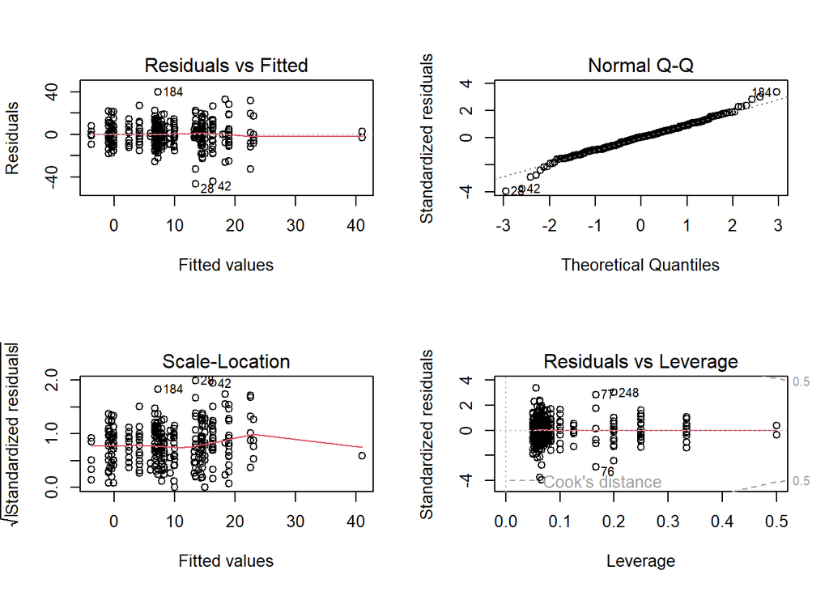

```r
par(mfrow=c(2,2))
plot(pygmalion_lm1)
```

```r
#refit without interaction and test for interaction effect
pygmalion_lm2 <- update(pygmalion_lm1, ~ . - Treatment:Class)
anova(pygmalion_lm2, pygmalion_lm1) # no evidence for an interaction effect, p-value = 0.11
```

```
## Analysis of Variance Table
##
## Model 1: Gain ~ Treatment + Class
## Model 2: Gain ~ Treatment + Class + Treatment:Class
##   Res.Df   RSS Df Sum of Sq     F Pr(>F)
## 1    302 45820
## 2    286 42332 16    3488.4 1.473 0.1086
```

```r
#refit without class and test for class effect
pygmalion_lm3 <- update(pygmalion_lm2, ~ . - Class)
anova(pygmalion_lm3, pygmalion_lm2) # strong evidence for a class effect, p-value < 0.0001
```

```
## Analysis of Variance Table
##
## Model 1: Gain ~ Treatment
## Model 2: Gain ~ Treatment + Class
##   Res.Df   RSS Df Sum of Sq     F    Pr(>F)
## 1    318 57106
## 2    302 45820 16     11286 4.649 2.228e-08 ***
## ---
## Signif. codes:  0 '***' 0.001 '**' 0.01 '*' 0.05 '.' 0.1 ' ' 1
```

```r
#run optimal model
pygmalion_lm <- lm(Gain ~ Treatment + Class, data = pygmalion)

summary(pygmalion_lm)
```

```
##
## Call:
## lm(formula = Gain ~ Treatment + Class, data = pygmalion)
##
## Residuals:
##     Min      1Q  Median      3Q     Max
## -47.714  -7.310  -0.303   6.885  42.698
##
## Coefficients:
##                    Estimate Std. Error t value Pr(>|t|)
## (Intercept)          7.1885     2.9049   2.475  0.01389 *
## Treatmentpygmalion   3.6076     1.7457   2.067  0.03963 *
## Class1b              7.5257     4.0605   1.853  0.06480 .
## Class1c             11.4662     4.1070   2.792  0.00557 **
## Class2a              0.5057     3.8212   0.132  0.89480
## Class2b              1.5278     4.1712   0.366  0.71441
## Class2c              1.1161     4.1712   0.268  0.78921
## Class3a              3.9685     4.0468   0.981  0.32756
## Class3b             -6.0389     4.2323  -1.427  0.15465
## Class3c             -7.4684     4.1242  -1.811  0.07115 .
## Class4a             -0.7119     3.8866  -0.183  0.85480
## Class4b             -8.2318     4.0554  -2.030  0.04325 *
## Class4c             -7.0006     4.0605  -1.724  0.08572 .
## Class5a             10.7621     3.9693   2.711  0.00709 **
## Class5b              7.1379     4.4077   1.619  0.10640
## Class6a              6.5853     3.8456   1.712  0.08785 .
## Class6b              0.4921     4.1776   0.118  0.90631
## Class6c             -1.1767     4.3136  -0.273  0.78521
## ---
## Signif. codes:  0 '***' 0.001 '**' 0.01 '*' 0.05 '.' 0.1 ' ' 1
##
## Residual standard error: 12.32 on 302 degrees of freedom
## Multiple R-squared:  0.2088, Adjusted R-squared:  0.1642
## F-statistic: 4.687 on 17 and 302 DF,  p-value: 8.209e-09
```

```r
anova(pygmalion_lm)
```

```
## Analysis of Variance Table
##
## Response: Gain
##            Df Sum Sq Mean Sq F value    Pr(>F)
## Treatment   1    803  803.08   5.293   0.02209 *
## Class      16  11286  705.37   4.649 2.228e-08 ***
## Residuals 302  45820  151.72
## ---
## Signif. codes:  0 '***' 0.001 '**' 0.01 '*' 0.05 '.' 0.1 ' ' 1
```

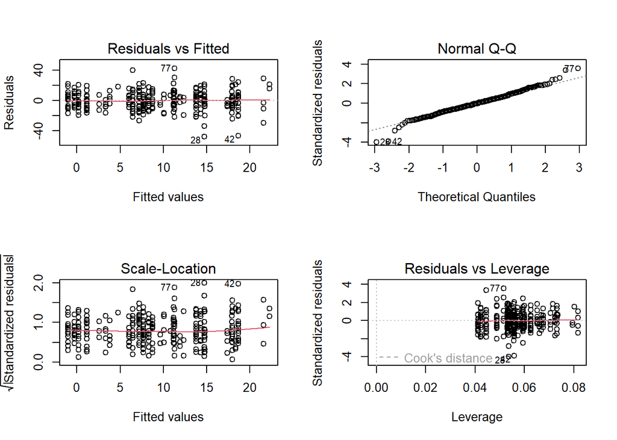

```r
par(mfrow=c(2,2))
plot(pygmalion_lm)
```

```r
confint(pygmalion_lm)
```

```
##                          2.5 %     97.5 %
## (Intercept)          1.4720406 12.9048877
## Treatmentpygmalion   0.1723438  7.0429480
## Class1b             -0.4647547 15.5161861
## Class1c              3.3842513 19.5482325
## Class2a             -7.0138819  8.0252837
## Class2b             -6.6803788  9.7360462
## Class2c             -7.0921435  9.3242815
## Class3a             -3.9950751 11.9320302
## Class3b            -14.3673784  2.2894944
## Class3c            -15.5840869  0.6473554
## Class4a             -8.3600906  6.9363598
## Class4b            -16.2122400 -0.2513132
## Class4c            -14.9910705  0.9898703
## Class5a              2.9510551 18.5731377
## Class5b             -1.5357916 15.8116371
## Class6a             -0.9822727 14.1527959
## Class6b             -7.7288265  8.7130061
## Class6c             -9.6652752  7.3119553
```

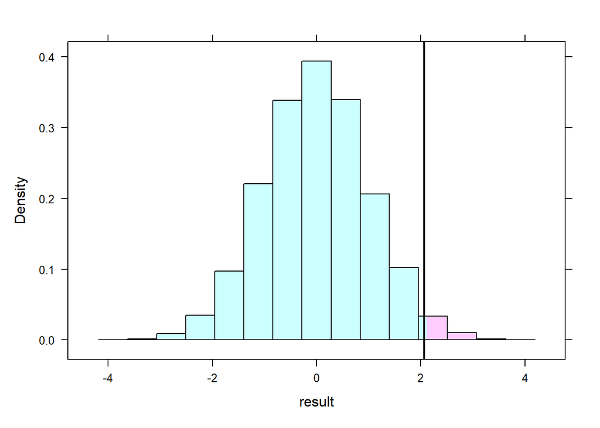

```r
#randomization distribution
obs = summary(lm(Gain ~ Treatment + Class, data = pygmalion))$coefficients["Treatmentpygmalion", "t value"]

nulldist = do(15000) * summary(lm(Gain ~ shuffle(Treatment) + shuffle(Class), data = pygmalion))$coefficients["shuffle(Treatment)pygmalion", "t value"]

histogram(~result, groups = result >= obs, v = obs, data = nulldist)
```

```r
tally(~result >= obs, format = "proportion", data = nulldist)
```

```
## result >= obs
##       TRUE      FALSE
## 0.02006667 0.97993333
```

**Supplemental 13.21_3rd** Excellent work. I couldn’t find any problems at all. **Score 2.5/2.5**